# Analysis

Fábio Lamaison Pinto

2024-01-22

## ANALYZE

###### FOR THE GOOGLE PROFESSIONAL DATA ANALYTICS CERTIFICATE CAPSTONE PROJECT - TRACK 1

This document comprises the analysis process step, for the track 1 of the Google’s professional data analytics certificate, where the main object is to find insights on how to help a fictional company called Cyclistic achieve their business goal of converting existing customers in to subscribers of their bike sharing program.

The data cleaning process was already completed, and comprises another R markdown file, both hosted on [my Kaggle](https://www.kaggle.com/fbiolamaisonpinto), the data being used for this project was sourced from https://divvy-tripdata.s3.amazonaws.com/index.html, and https://grg.org/.

### THE BIG PICTURE

The main goal for this analytic process will be to identify trends on how customers and subscribers use the bike sharing service, and then propose ways on how to design a marketing campaign to promote customers to become subscribers.

### USERS

I’ll start this process by viewing the share of entries for each user type, to have a grasp on the overall composition of the service users.

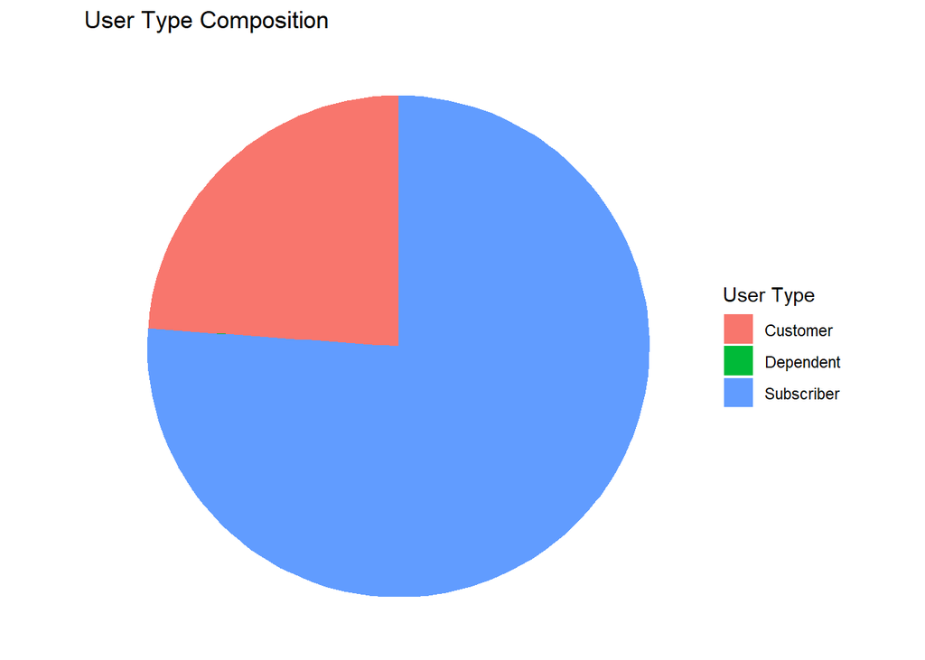

```r
ggplot(cyclistic_trips_2016) +
  geom_bar(mapping = aes(x = "", fill = user_type), width = 1) +
  coord_polar(theta = "y") +
  theme_void() +
  labs(title = "User Type Composition", fill = "User Type")
```

Analyzing the pie chart, it shows that more than 75% of entries are from subscribers of the service, while around 25% of the entries are from customers, at first sight it is important to notice that these entries do not correspond each to a single user, but to a single ride, what gives the possibility to in fact have a bigger amount of customers that use the service fewer times, and a lesser amount of subscribers that use the service more times, resulting in more entries, but something that doesn’t leave much space for thought, is that there are very few dependents user type, due to that and to ease presentation, these entries will be hidden from the analysis.

```r
cyclistic_trips_2016 <- cyclistic_trips_2016 %>%
  filter(user_type !="Dependent")
```

Having an initial notion of user type composition, and filtering out dependents, lets analyse the age and gender of our subscribers, to have an initial grasp on who they are, remember that gender and age weren’t provided for customers.

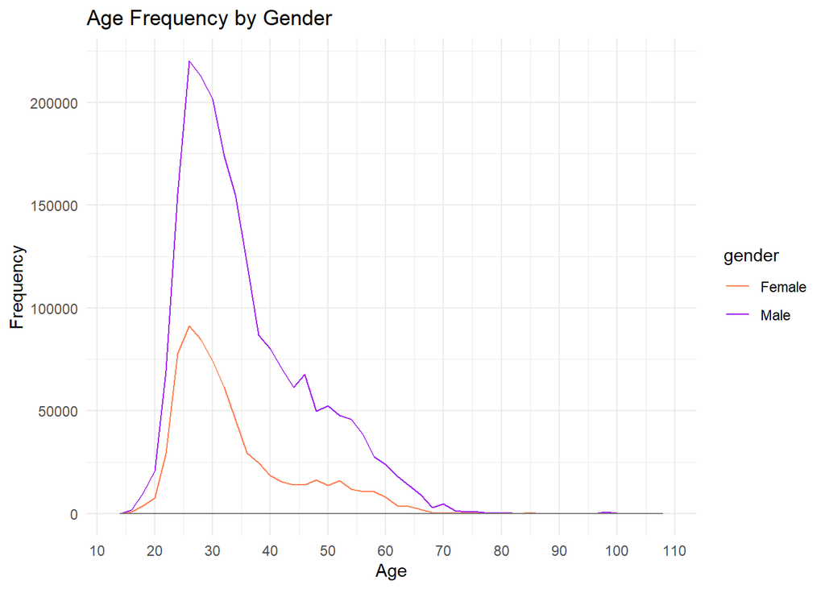

```r
subscribers <- cyclistic_trips_2016 %>%
  filter(user_type == "Subscriber")

ggplot(subscribers, aes(x = age, color = gender)) +
  theme_minimal() +
  geom_freqpoly(binwidth = 2, position = "identity") +
  labs(title = "Age Frequency by Gender", x = "Age", y = "Frequency") +
  scale_color_manual(values = c("Male" = "purple", "Female" = "coral")) +
  scale_x_continuous(breaks = seq(10, 110, by = 10))
```

As it shows most entries are from subscribers are around the age of 26, the entries of male subscribers are usually more than the double of the amount of female subscribers entries, the age range for males that have more than 50000 entries span from right after 20 years to around 50 years, for females this span also starts around 20 years, but go only as far as close to 34 years of age, the presence of entries past 75 years of age is close to none.

### TRIPS

Now lets analyse the frequency of trips per month grouped by user type, this will help on understanding how weather may affect user activity, preferred periods of usage, and hint on what data we should further focus.

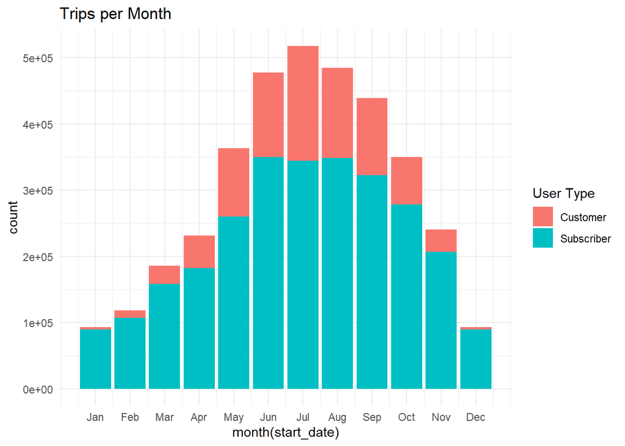

```r
month_labels <- c("Jan", "Feb", "Mar", "Apr", "May", "Jun", "Jul", "Aug", "Sep", "Oct", "Nov", "Dec")

ggplot(cyclistic_trips_2016) +
  geom_bar(mapping = aes(x = month(start_date), fill = user_type)) +
  scale_x_continuous(breaks = 1:12, labels = month_labels) +
  theme_minimal() +
  labs(title = "Trips per Month", fill = "User Type")
```

The above bar chart shows January and December being the months of least activity, with a smashing proportion in favor of subscribers, having almost no activity from customers, while June, July and August show the most activity for all types of users, having a bigger participation from customers in comparison to what is seen in the months of least activity.

Customer activity presents a clear pattern of growth from winter to summer, and shrinking from summer to winter where there is almost no activity, a seasonal pattern that benefits hotter days, this information paired with the information that 30% of users use the service to commute to work (given by the company) points out to their primary interest in the service being of leisure, and that the ones using the service to commute to work are mainly subscribers, if not all.

Subscriber activity although increases in the summer, it stills significantly present during cold periods, what indicated that some subscribers use the service all year around, possibly to daily use transportation, a curious characteristic shown in the graph is that subscriber usage actually falls a bit during July, to after regain momentum before starting to lose it again towards winter, this may be due to younger subscribers entering their vacation time, what leads to them not using the service for daily transportation in this period.

For the sake of brevity I’ll not go as far as putting these theories through detailed evaluation tests, having discovered the most and least active months for the service, and the proportion between user types throughout the year, I’ll go further on distinguishing user type behavior based on trip max and mean length.

```r
cyclistic_trip_metrics <- data.frame(
  row.names = c("Mean", "Max"),
  Customer = c(0.00,0.00),
  Subscriber = c(0.00,0.00)
)


cyclistic_trip_metrics["Mean", "Customer"] <- cyclistic_trips_2016 %>%
  filter(user_type == "Customer") %>%
  summarise(mean(trip_duration, na.rm = TRUE)/60)

cyclistic_trip_metrics["Max", "Customer"] <- cyclistic_trips_2016 %>%
  filter(user_type == "Customer") %>%
  summarise(max(trip_duration, na.rm = TRUE)/60)

cyclistic_trip_metrics["Mean", "Subscriber"] <- cyclistic_trips_2016 %>%
  filter(user_type == "Subscriber") %>%
  summarise(mean(trip_duration, na.rm = TRUE)/60)

cyclistic_trip_metrics["Max", "Subscriber"] <- cyclistic_trips_2016 %>%
  filter(user_type == "Subscriber") %>%
  summarise(max(trip_duration, na.rm = TRUE)/60)

cyclistic_trip_metrics["Max", "Relation"] <- cyclistic_trip_metrics %>%
  summarise(cyclistic_trip_metrics["Max", "Customer"]/cyclistic_trip_metrics["Max", "Subscriber"])

cyclistic_trip_metrics["Mean", "Relation"] <- cyclistic_trip_metrics %>%
  summarise(cyclistic_trip_metrics["Mean", "Customer"]/cyclistic_trip_metrics["Mean", "Subscriber"])

cyclistic_trip_metrics <- cyclistic_trip_metrics %>%
  mutate_all(round, digits = 2)

print(cyclistic_trip_metrics)
```

```
##      Customer Subscriber Relation
## Mean    30.96      12.03     2.57
## Max   1457.00    1437.00     1.01
```

On the table above is presented the mean and max trip duration in minutes, according to user type, and the relation of these metrics between each user type, the mean duration of a Customer trip is 2.57 times longer than the one of a Subscriber, while the max duration is pretty much the same.

The recurrence of data that leads to the thesis that customers use the service for leisure while subscribers use it for daily transportation keeps coming up, lets go a step further in this direction and see if subscribers are more active during week days than customers.

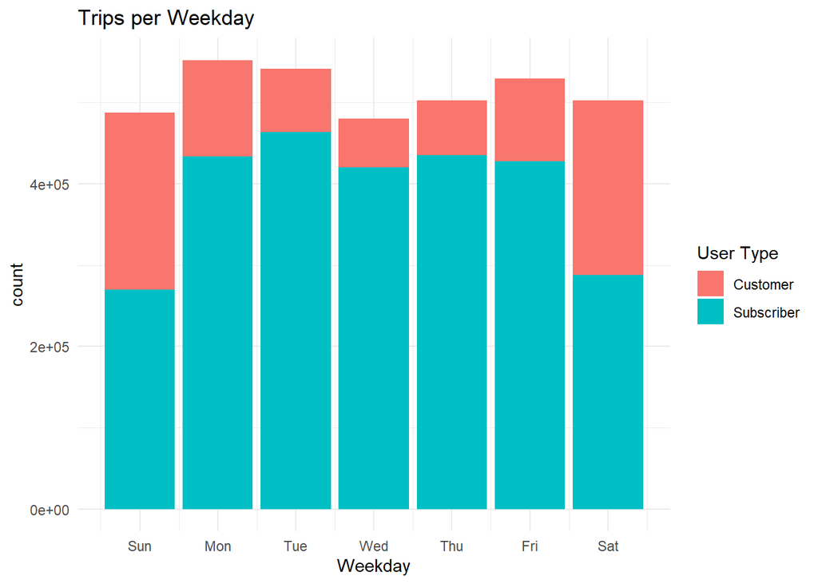

```r
weekday_labels <- c("Sun", "Mon", "Tue", "Wed", "Thu", "Fri", "Sat")

ggplot(cyclistic_trips_2016) +
  geom_bar(mapping = aes(x = wday(start_date), fill = user_type)) +
  scale_x_continuous(breaks = 1:7, labels = weekday_labels) +
  theme_minimal() +
  labs(title = "Trips per Weekday", fill = "User Type", x = "Weekday")
```

It is perfectly clear that customers prefer to use the service on and around weekends, while subscribers prefer the weekdays, even though they also use the service on weekends, and still have more entries on these dates than customers.

### STATIONS

Now lets check if there are differences on the preference for stations between user types, by ranking stations based on their occurrence in the data frame, and grouping them by user type.

```r
station_entries <- data.frame(
  station = c(cyclistic_trips_2016$from_station_name, cyclistic_trips_2016$to_station_name),
  user_type = c(cyclistic_trips_2016$user_type, cyclistic_trips_2016$user_type)
                       )
grouped_stations <- station_entries %>%
  group_by(user_type = user_type, name = station) %>%
  summarize(count = n())
popular_stations <- grouped_stations %>%
  arrange(desc(count))

head(popular_stations, 10)
```

```
## # A tibble: 10 × 3
## # Groups:   user_type [2]
##    user_type  name                          count
##    <chr>      <chr>                         <int>
##  1 Customer   Streeter Dr & Grand Ave      150578
##  2 Subscriber Clinton St & Washington Blvd  88957
##  3 Customer   Lake Shore Dr & Monroe St     79156
##  4 Subscriber Clinton St & Madison St       73094
##  5 Subscriber Canal St & Madison St         71078
##  6 Subscriber Canal St & Adams St           60875
##  7 Customer   Lake Shore Dr & North Blvd    58898
##  8 Subscriber Kingsbury St & Kinzie St      57898
##  9 Customer   Theater on the Lake           56005
## 10 Customer   Millennium Park               53772
```

Even though customer entries are less than a third of subscribers, the most entries for a same station grouped by user type belong to them, with 150578 entries for the Streeter Dr & Grand Ave, they hold half of the spots for the top 10 entries list, indicating that customers activity is more concentrated on certain stations, and subscribers more disperse.

A quick search online shows that the top 5 stations for customers are all located close to the lake, on leisure and tourist oriented areas, while subscribers preferred stations are located deeper in the city, in more service oriented areas. Lets end this analysis by plotting station occurrence over the map of Chicago, so users station preference can be better accessed, for this I will use a data frame containing id, name and geographical coordinates, that was previously cleaned, and a KML file of the Chicago city boundaries.

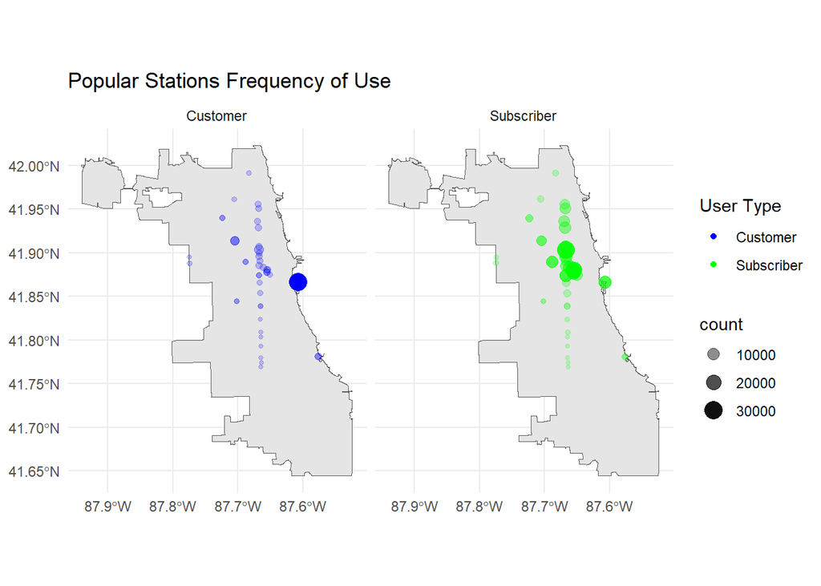

```r
stations <- merge(popular_stations, stations_coord, by = "name", all.x = TRUE)

points_df <- stations %>%
  filter(!is.na(latitude) & !is.na(longitude))

points_sf <- st_as_sf(points_df, coords = c("longitude", "latitude"), crs = 4326)

ggplot() +
  geom_sf(data = chicago_map) +
  geom_sf(data = head(points_sf,90), aes(color = user_type, size = count, alpha = count))+
  scale_color_manual(values = c("Customer" = "blue", "Subscriber" = "green")) +
  scale_size_continuous(range = c(1, 5)) +
  scale_alpha_continuous(range = c(0.2, 1)) +
  theme_minimal() +
  labs(title = "Popular Stations Frequency of Use", color = "User Type") +
  facet_wrap(~user_type)
```